# GPA Analysis

Celeste

2017年6月26日

大家都說管理學院課很甜輕鬆，GPA很好拿，為了探討是否屬實， 我們利用爬蟲將 http://ntusweety.herokuapp.com/ 近年課程、GPA的歷史紀錄爬下來存到course.txt， 第一步將檔案讀進來

```r
course.path <- "C:/Users/Celeste/Desktop/rrr/course.txt"
readBin(course.path, what = "raw", n = 3)
```

```
## [1] 39 37 30
```

```r
readLines(file(course.path, encoding = "UTF-8"), n = 5)
```

```
## [1] "97020\t002\t柔道初級\t3.69\t黃國恩\thttp://ntusweety.herokuapp.com/history?&id=002+50440&cl=22"
## [2] "97023\t002\t手球中級\t3.93\t黃欽永\thttp://ntusweety.herokuapp.com/history?&id=002+50570&cl=16"
## [3] "97032\t002\t游泳初級\t3.63\t許君恆\thttp://ntusweety.herokuapp.com/history?&id=002+50630&cl=D5"
## [4] "97033\t002\t游泳初級\t3.85\t許君恆\thttp://ntusweety.herokuapp.com/history?&id=002+50630&cl=D6"
## [5] "97034\t002\t游泳初級\t3.7\t林怡秀\thttp://ntusweety.herokuapp.com/history?&id=002+50630&cl=F8"
```

```r
info <- file.info(course.path)
course.bin <- readBin(course.path, what = "raw", n = info$size)
library(stringi)
course.txt <- stri_encode(course.bin, "UTF-8", "UTF-8")
get_text_connection_by_l10n_info <- function(x) {
  info <- l10n_info()
  if (info$MBCS & !info$`UTF-8`) {
    textConnection(x)
  } else {
    textConnection(x, encoding = "UTF-8")
  }
}
course <- read.table(get_text_connection_by_l10n_info(course.txt), header = FALSE, sep = "\t")
colnames(course) <- c("class.num", "department.num", "course","avgGPA", "prof.","href")
```

# 表一：課程成績資料表(部分)

```r
library(dplyr)
slice(course, 100:110)
```

```
##    class.num department.num               course avgGPA  prof.
## 1      84988            101               藏文二   3.98 曾德明
## 2      15335            101               滿文一   4.13 莊吉發
## 3      73933            101               滿文二   4.12 莊吉發
## 4      41556            101 八思巴蒙古語文獻選讀   4.20 蕭素英
## 5      39892            102       西洋文學概論二   3.41 劉雅詩
## 6      32182            102       西洋文學概論二   3.59 姜台芬
## 7      46168            102       文學作品讀法下   3.40 高瑟濡
## 8      13310            102       文學作品讀法下   3.48 李紀舍
## 9      36429            102       文學作品讀法下   3.51 王沐嵐
## 10     56760            102           期刊編寫一   4.27 奇邁可
## 11     65356            102         語言學概論下   3.58 林祐瑜
##                                                          href
## 1    http://ntusweety.herokuapp.com/history?&id=101+51420&cl=
## 2    http://ntusweety.herokuapp.com/history?&id=101+51510&cl=
## 3    http://ntusweety.herokuapp.com/history?&id=101+51520&cl=
## 4    http://ntusweety.herokuapp.com/history?&id=101+51800&cl=
## 5  http://ntusweety.herokuapp.com/history?&id=102+14120&cl=01
## 6  http://ntusweety.herokuapp.com/history?&id=102+14120&cl=03
## 7  http://ntusweety.herokuapp.com/history?&id=102+14202&cl=01
## 8  http://ntusweety.herokuapp.com/history?&id=102E14202&cl=02
## 9  http://ntusweety.herokuapp.com/history?&id=102+14202&cl=03
## 10   http://ntusweety.herokuapp.com/history?&id=102E20610&cl=
## 11 http://ntusweety.herokuapp.com/history?&id=102+21112&cl=01
```

因為要做的是管院GPA和其他學院比較，資料中缺少學院資料，這裡讀取另一個檔案“college_info.txt”， 裡面有各學院名稱與簡碼資料，將檔案讀入後以left_join連結上一張表，並以“department.num”(課號)與“num”做鍵結

```r
college.path <- "C:/Users/Celeste/Desktop/rrr/college_info.txt"
readBin(college.path, what = "raw", n = 3)
```

```
## [1] 6e 75 6d
```

```r
readLines(file(college.path, encoding = "BIG5"), n = 5)
```

```
## [1] "num  Department  College" "101  中文系  文學院"
## [3] "102  外文系  文學院"      "103  歷史系  文學院"
## [5] "104  哲學系  文學院"
```

```r
college.info <- file.info(college.path)
college.bin <- readBin(college.path, what = "raw", n = college.info$size)
library(stringi)
college.txt <- stri_encode(college.bin, "BIG5", "UTF-8")
college.info <- read.table(get_text_connection_by_l10n_info(college.txt), header = TRUE)
course.mix <- left_join(course,college.info,by = c("department.num" = "num"))
```

接下來，我們先來看看各系的平均GPA #表二：系平均GPA

```r
departmentGPA <- local({
  group_by(course.mix, Department) %>%
  summarise(GPA = mean(avgGPA)) %>%
    arrange(GPA)})
departmentGPA
```

```
## Source: local data frame [55 x 2]
##
##    Department      GPA
##        (fctr)    (dbl)
## 1      數學系 2.674815
## 2      機械系 2.975926
## 3    工科海洋 3.163333
## 4      物理系 3.207719
## 5      材料系 3.246250
## 6      大氣系 3.250769
## 7      植微系 3.280000
## 8      會計系 3.312759
## 9      心理系 3.338750
## 10     經濟系 3.340000
## ..        ...      ...
```

前五名平均課程GPA最高的系竟然有電機和資工，有點不合理，經訪問和觀察資料，發現專題課程拉高平均非常多，幾乎都是A+，而電資學院其他課程GPA都很低，為了使資料更貼近現實，統一對所有資料刪除“專題研究”，和有關“專題”的課程。 而GPA最低的數學、機械、物理等等不意外….辛苦了。值得注意的是，大家認為管院成績很好拿，其中的會計系平均課程給的GPA只有3.31，位於所有系倒數前幾低！ #表三：扣掉專題研究的系所GPA

```r
a <- filter(course.mix, grepl(pattern = "專題", x = course, fixed = TRUE))
course.mix <- course.mix[!(course.mix$course == "專題研究"),]
course.mix <- anti_join(course.mix, a)
departmentGPA_modified <- local({
  group_by(course.mix,Department) %>%
  summarise(GPA = mean(avgGPA, na.rm = TRUE))%>%
    arrange(GPA)})
departmentGPA_modified
```

```
## Source: local data frame [55 x 2]
##
##    Department      GPA
##        (fctr)    (dbl)
## 1      數學系 2.625385
## 2      機械系 2.975926
## 3      資管系 3.069091
## 4  生物機電系 3.132105
## 5      化工系 3.162273
## 6    工科海洋 3.163333
## 7      物理系 3.207719
## 8      生工系 3.208182
## 9      材料系 3.246250
## 10     大氣系 3.250769
## ..        ...      ...
```

拿掉專題課程後的GPA，數學系依然墊底，管院中的資管系也很辛苦，倒數第三低GPA不好拿，會計系也是。 而工管和國企課程平均GPA挺高的，但也沒有到名列前茅的好拿高分。 學系比較完，我們來看看，管院究竟有沒有好拿高分？

# 表四：學院給分GPA(Modified)比較

```r
library(ggplot2)
collegeGPA_modified <- local({
  group_by(course.mix, College) %>%
  summarise(GPA = mean(avgGPA, na.rm = TRUE))%>%
    arrange(desc(GPA))})
collegeGPA_modified
```

```
## # A tibble: 12 × 2
##       College      GPA
##        <fctr>    <dbl>
## 1      醫學院 3.713373
## 2    公衛學院 3.623125
## 3      文學院 3.594577
## 4      法學院 3.583929
## 5          NA 3.533629
## 6    生農學院 3.502996
## 7  生命科學院 3.476957
## 8      社科院 3.421818
## 9    管理學院 3.389101
## 10   電資學院 3.376410
## 11     工學院 3.314416
## 12     理學院 3.280213
```

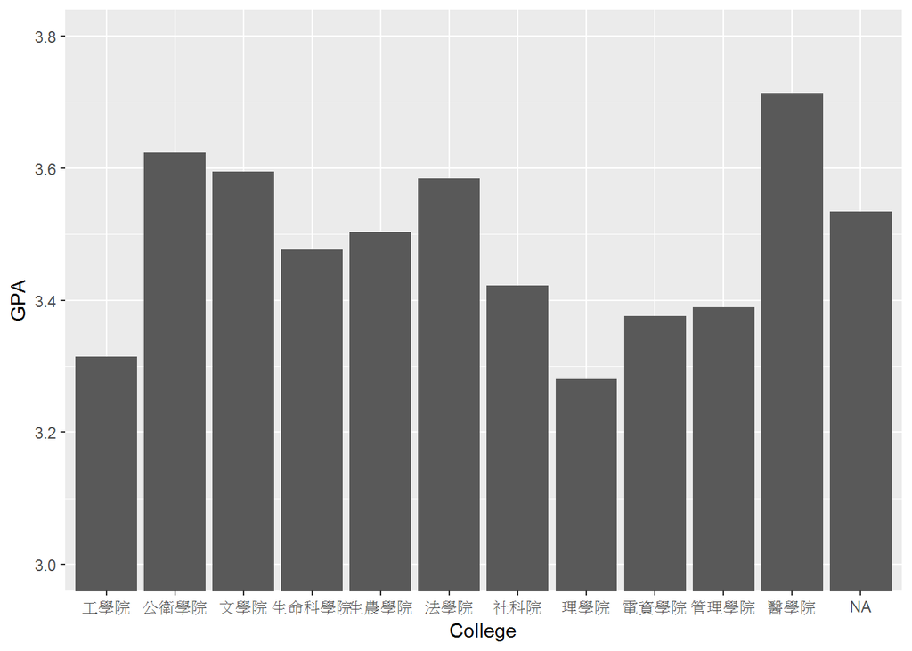

```r
dat <- local({
  group_by(course.mix, College) %>%
    summarise(GPA = mean(avgGPA, na.rm = TRUE))
})
g2 <- ggplot(dat, aes(x = College, y = GPA)) + geom_bar(stat = "identity")
g2 + coord_cartesian(ylim = c(3,3.8))
```

並沒有！管院的成績只比電資和理工學院好拿而已！大家都是辛苦人

```r
totalAvgGPA <- mean(departmentGPA_modified$GPA)
totalAvgGPA
```

```
## [1] 3.450751
```

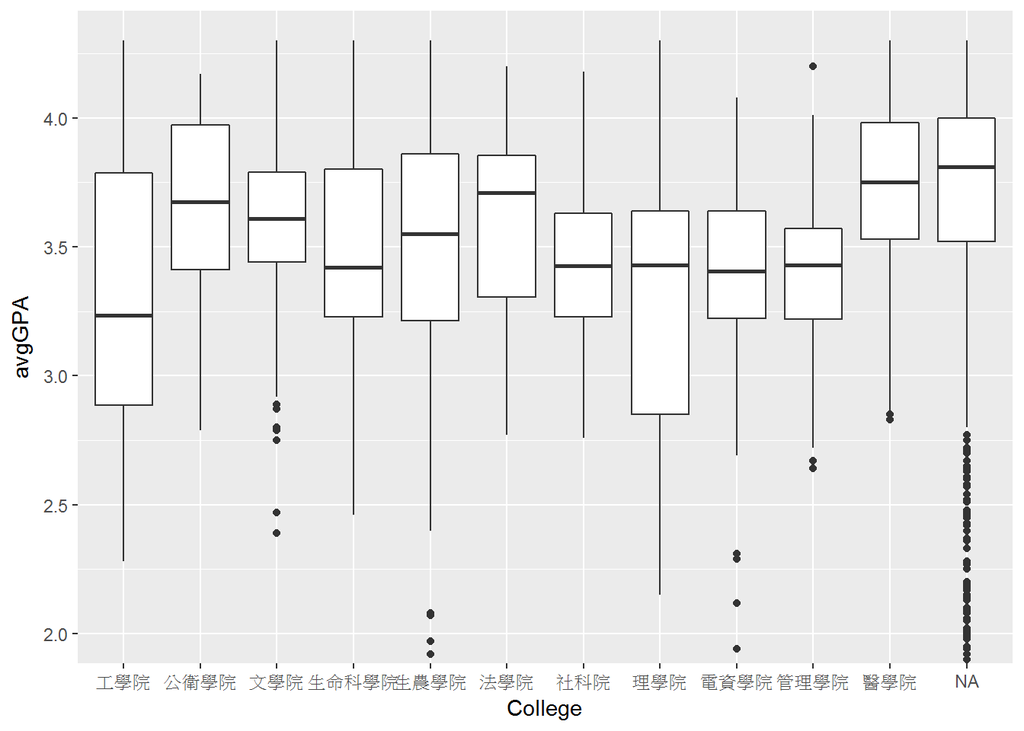

```r
#GPA平均學院比較盒狀圖
dat2 <- local({
  group_by(course.mix, College)
})
g2 <- ggplot(dat2, aes(x = College, y = avgGPA)) + geom_boxplot()
g2 + coord_cartesian(ylim = c(2,4.3))
```

再仔細一點，全部學院平均課程GPA是3.45，管院只有只有3.39 電資、管理、社科、理工學院GPA都低於平均。

# 表五：所有學院、學系GPA視覺化比較

```r
dat2 <- local({
  group_by(course.mix, College,Department) %>%
    summarise(GPA = mean(avgGPA, na.rm = TRUE))
})
library(ggrepel)
```

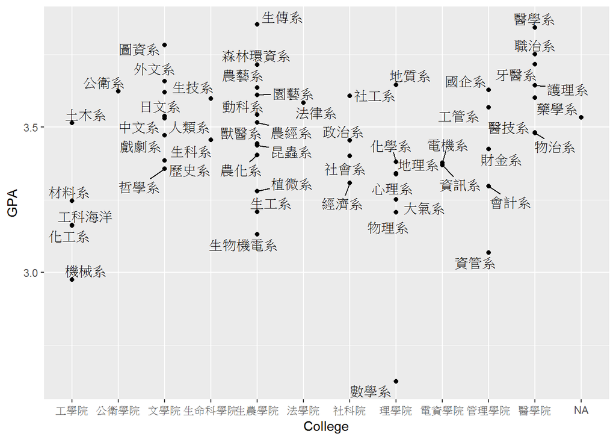

```r
ggplot(dat2, aes(x = College, y = GPA)) + geom_point() +
  geom_text_repel(aes(x=College,y= GPA,label=Department))
```

[figure not shown]

```r
dat3 <- local({
  filter(course.mix, College == "公衛學院" | College == "管理學院" | College == "文學院" | College =="法學院"
         | College == "醫學院" |  College == "理學院") %>%
  group_by(Department) %>%
    select(Department, avgGPA)
})
g <- ggplot(dat3, aes(x = Department, y = avgGPA))
g + geom_boxplot()
```

國企、工管GPA給分都蠻甜，高於整體平均GPA，系內各課程給分差距也很小； 資管系GPA的慘度更勝理工學院，會計系也蠻可憐，給分比較硬。 反觀其他學院，其實很多平均GPA和整體學院分布都比管院更好拿分數。 值得注意的是，數學系給分平均和整體都很低…..真的是辛苦了!